# examining possible scale parameter corrections

Arnie Seong

02 February 2026

## Results context

```r
img_suffixes <- c(paste0("_e", 1:9, "e_+05.png"), "_e1e_+06.png")

stem_pvtau1 <- here::here("sims", "results", "hshoe_smooth_pvtau_1721632_12500obs_")
stem_pvtau2 <- here::here("sims", "results", "hshoe_smooth_pvtau_2721632_12500obs_")
seed_pvtau2 <- c(19709, 809872, 264744, 498729, 336130, 263808, 877164, 218489, 234821, 616240)
seed_pvtau1 <- c(561114, 453639, 663173, 108703, 165780)

resfile_pvtau1 <- paste0(stem_pvtau1, seed_pvtau1, ".RData")
modfile_pvtau1 <- paste0(stem_pvtau1, seed_pvtau1, ".pt")

resfile_pvtau2 <- paste0(stem_pvtau2, seed_pvtau2, ".RData")
modfile_pvtau2 <- paste0(stem_pvtau2, seed_pvtau2, ".pt")
```

# Modifying $Z_1$:

$$Z_1 W_1 Z_2 = \left\{ z_{1_j} w_{j,k}
z_{2_k} \right\}$$

- checking if using geometric or simple mean of $z^2_2$ (second layer shrinkage) would help:
  - `ztilsq_2` = $\tilde{z}_2^2$; local shrinkage only
  - `zsq_2` = $z_2^2 = \tilde{z}_2^2 s_2^2$; including global shrinkage parameter for layer 2, $s_2$

Here, just checking to see if this would actually be any good as a correction (increasing separation, or mitigating effect of such small $\tau$ since separation in $\tilde{z}$ is already v. good)

```r
resfiles <- c(resfile_pvtau1, resfile_pvtau2)
modfiles <- c(modfile_pvtau1, modfile_pvtau2)
zsq_means <- matrix(NA, nrow = length(resfiles), ncol = 2)
colnames(zsq_means) <- c("geom mean", "simple mean")
ztilsq_means <- z_means <- ztil_means <- zsq_means

for (sim_ind in 1:length(resfiles)){
  load(resfiles[sim_ind])
  nn_mod <- torch::torch_load(modfiles[sim_ind])

  ztilsq_2 <- get_ztil_sq(nn_mod$fc2)
  ztil_2 <- sqrt(ztilsq_2)
  ssq_2 <- get_s_sq(nn_mod$fc2)
  zsq_2 <- ztilsq_2 * ssq_2

  zsq_means[sim_ind, ] <- c(geom_mean(zsq_2), mean(zsq_2))
  ztilsq_means[sim_ind, ] <- c(geom_mean(ztilsq_2), mean(ztilsq_2))
  z_means[sim_ind, ] <- c(geom_mean(sqrt(zsq_2)), mean(sqrt(zsq_2)))
  ztil_means[sim_ind, ] <- c(geom_mean(sqrt(ztilsq_2)), mean(sqrt(ztilsq_2)))

}

mykable(round(zsq_means, 4), cap = "$z_2^2$ means from 15 sims")
```

$z_2^2$ means from 15 sims

| geom mean | simple mean |
| --- | --- |
| 0.0006 | 0.0558 |
| 0.0012 | 0.3395 |
| 0.0002 | 0.0157 |
| 0.0024 | 0.3186 |
| 0.0004 | 0.0082 |
| 0.0002 | 0.0408 |
| 0.0001 | 0.0114 |
| 0.0063 | 0.1538 |
| 0.0003 | 0.0353 |
| 0.0001 | 0.0109 |
| 0.0030 | 0.1407 |
| 0.0001 | 0.0145 |
| 0.0002 | 0.0157 |
| 0.0029 | 0.1483 |
| 0.1932 | 2.2049 |

```r
mykable(round(ztilsq_means, 4), cap = "$\\tilde{z}_2^2$ means from 15 sims")
```

$\tilde{z}_2^2$ means from 15 sims

| geom mean | simple mean |
| --- | --- |
| 0.0597 | 5.9159 |
| 0.0535 | 15.6421 |
| 0.0468 | 3.5544 |
| 0.0969 | 12.9645 |
| 0.0835 | 1.8120 |
| 0.0283 | 4.9900 |
| 0.0263 | 2.2393 |
| 0.2665 | 6.5037 |
| 0.0386 | 4.7695 |
| 0.0252 | 3.2432 |
| 0.2205 | 10.2900 |
| 0.0245 | 3.2487 |
| 0.0423 | 3.3674 |
| 0.2594 | 13.2565 |
| 0.6042 | 6.8959 |

```r
mykable(round(z_means, 4), cap = "$z_2$ means from 15 sims")
```

$z_2$ means from 15 sims

| geom mean | simple mean |
| --- | --- |
| 0.0237 | 0.1556 |
| 0.0341 | 0.3289 |
| 0.0144 | 0.0886 |
| 0.0488 | 0.3282 |
| 0.0194 | 0.0740 |
| 0.0152 | 0.1303 |
| 0.0116 | 0.0802 |
| 0.0794 | 0.2751 |
| 0.0169 | 0.1190 |
| 0.0092 | 0.0702 |
| 0.0549 | 0.2411 |
| 0.0104 | 0.0827 |
| 0.0141 | 0.0855 |
| 0.0539 | 0.2302 |
| 0.4395 | 1.0983 |

```r
mykable(round(ztil_means, 4), cap = "$\\tilde{z}_2$ means from 15 sims")
```

$\tilde{z}_2$ means from 15 sims

| geom mean | simple mean |
| --- | --- |
| 0.2443 | 1.6024 |
| 0.2314 | 2.2328 |
| 0.2163 | 1.3338 |
| 0.3113 | 2.0938 |
| 0.2889 | 1.0996 |
| 0.1682 | 1.4404 |
| 0.1623 | 1.1223 |
| 0.5162 | 1.7889 |
| 0.1965 | 1.3835 |
| 0.1589 | 1.2085 |
| 0.4695 | 2.0624 |
| 0.1564 | 1.2401 |
| 0.2057 | 1.2516 |
| 0.5093 | 2.1771 |
| 0.7773 | 1.9424 |

- the only version that would help is multiplying by the simple mean of $\tilde{z}_2^2$, but I’d have a hard time justifying it (why only the local shrinkage parameter from the 2nd layer?).
  - well, actually, maybe a justification would be as a correction to the 1st layer’s global shrinkage $s_1$. But if anything, I would think dividing $s_1$ by the geometric mean of $\tilde{z}_2$ would make more sense ()
    - $\tilde{z}_2$ are the local scale parameters in layer 2; the output of neurons in layer 1 get multiplied by these. If $\tilde{z}_{2_j}$ is small, then the $j$<sup>th</sup> neuron’s output is shrunk. An argument could be made that the mean or geometric mean of $\tilde{z}_2$ is a metric for how many 1st layer neurons retain relevance. **1)** If the mean of $\tilde{z}_2$ is $\geq 1$, the layer 1 global scale param $\tau_1$ is probably well-calibrated in relation to the number of neurons in layer 1 (proportion of included/total number of weights would be same). **2)** if the mean of $\tilde{z}_2$ is small (near 0), then $\tau_1$ is likely smaller than it “should” be. Pursuing this in the next section:

# Correcting $\tau_1$

Can we create a kappa-based metric for how “shrunk” $\tau_1$ is? Dividing by mean $\kappa_j$ from the next layer?

Actually, Piironen & Vehtari 2017 have a measure for the number of effective coefficients: $m_{eff} = \sum_{j = 1}^{p} \left(1 - \kappa_{j} \right)$. We could take the $m_{eff}$ generated by the 2nd layer (which does the same thing that the 1st layer does, i.e. horseshoe prior on coefs).

- Then we could correct $\tau_1$ by **the number of neurons in layer 1 ($d_1$) divided by the effective number of neurons**, i.e. corrected global scale parameter $\tau_1^{corr}$ would be given by:

$$\tau_1^{corr} = \hat{\tau}_1 \times
\left[ \dfrac{d_1}{m_2^{eff}} \right]$$

```r
sim_ind <- 0
m_eff <- function(nn_layer){
  k <- get_kappas(nn_layer)
  sum(1 - k)
}
```

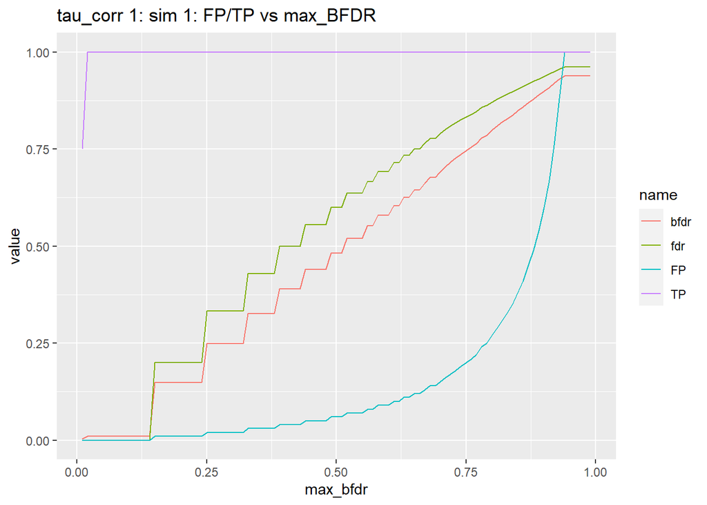

```r
sim_ind <- sim_ind + 1
load(resfiles[sim_ind])
nn_mod <- torch::torch_load(modfiles[sim_ind])

ztilsq_1 <- get_ztil_sq(nn_mod$fc1)
ssq_1 <- get_s_sq(nn_mod$fc1)
ztilsq_2 <- get_ztil_sq(nn_mod$fc2)
ssq_2 <- get_s_sq(nn_mod$fc2)

zsq_1 <- ztilsq_1 * ssq_1
zsq_2 <- ztilsq_2 * ssq_2

zsq_1_tc <- zsq_1 * (16 / m_eff(nn_mod$fc2))^2
k_1_tc <- (1 + zsq_1_tc)^(-1)
err_mat <- err_by_max_bfdr(k_1_tc)$err_mat
err_mat[, 1:5] %>%
  as_data_frame() %>%
  pivot_longer(cols = -max_bfdr) %>%
  ggplot(aes(y = value, x = max_bfdr, color = name)) +
  geom_line() +
  labs(
    title = paste0("tau_corr 1: sim ", sim_ind, ": FP/TP vs max_BFDR")
  )
```

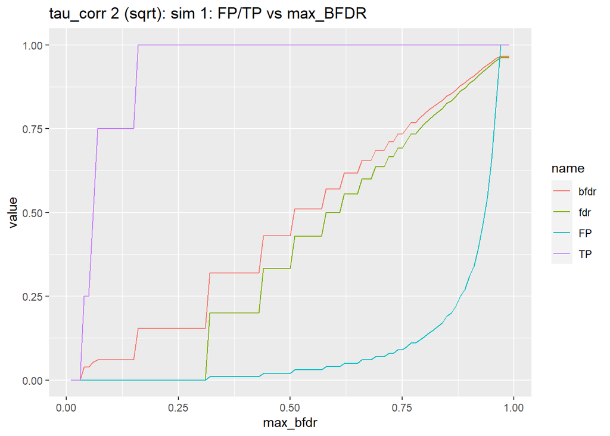

```r
zsq_1_tc2 <- zsq_1 * (16 / m_eff(nn_mod$fc2))
k_1_tc2 <- (1 + zsq_1_tc2)^(-1)
err_mat2 <- err_by_max_bfdr(k_1_tc2)$err_mat
err_mat2[, 1:5] %>%
  as_data_frame() %>%
  pivot_longer(cols = -max_bfdr) %>%
  ggplot(aes(y = value, x = max_bfdr, color = name)) +
  geom_line() +
  labs(
    title = paste0("tau_corr 2 (sqrt): sim ", sim_ind, ": FP/TP vs max_BFDR")
  )
```

```r
# err_mat[1:20, 1:5]
```

This actually looks amazingly good! The BFDRs actually match the FDRs fairly well (didn’t plot before b/c they were completely different from each other), and the TPR/FPR plot looks awesome overall.

Let’s see if this applies across the different simulations:

## other simulations: $\tau_1^{corr}$

### sim 2

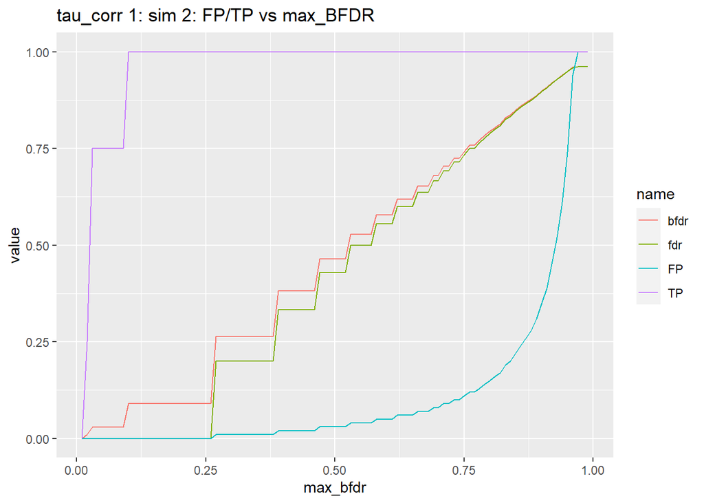

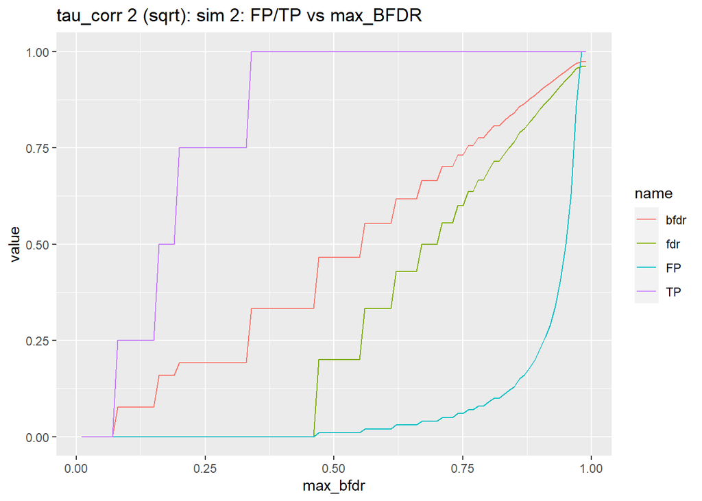

### sim 3

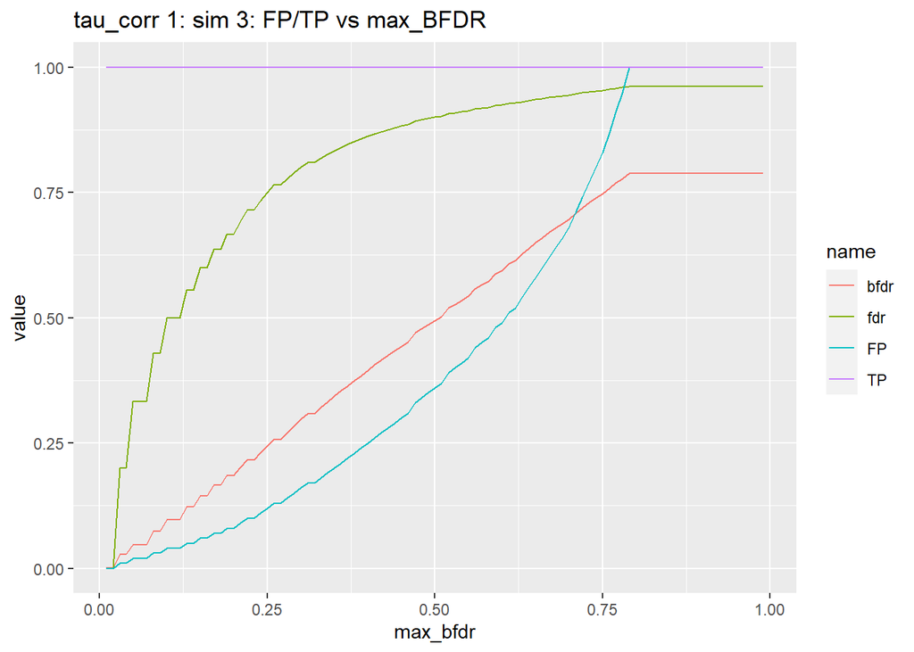

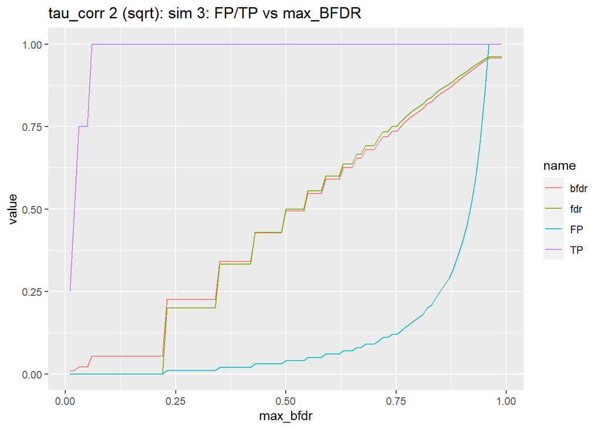

### sim 4

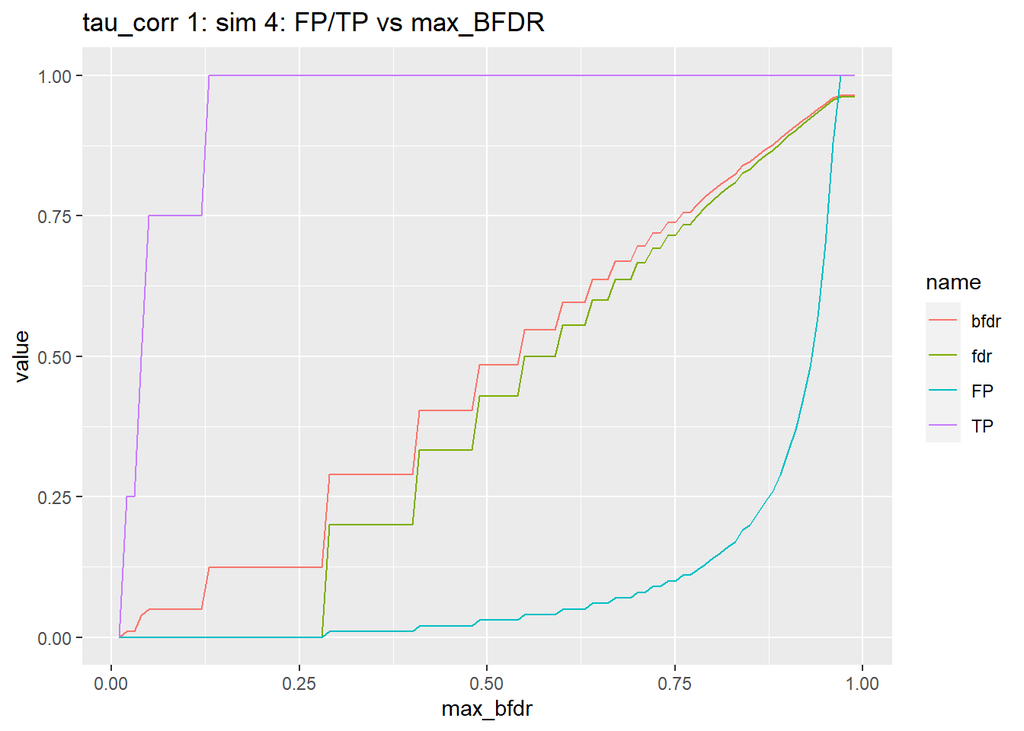

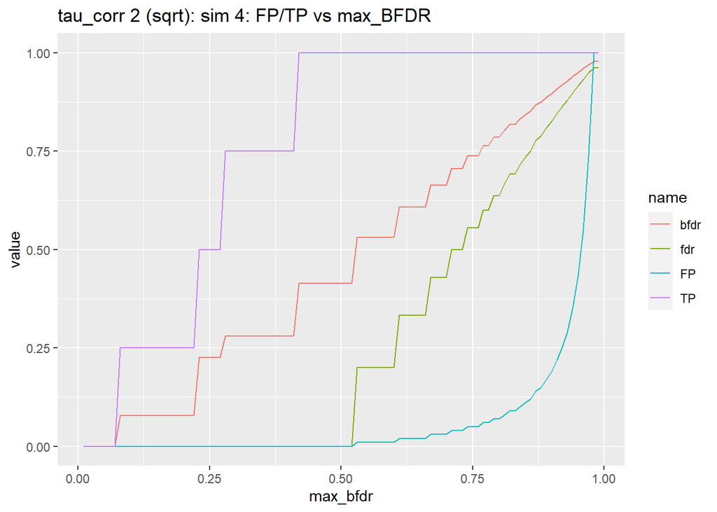

### sim 5

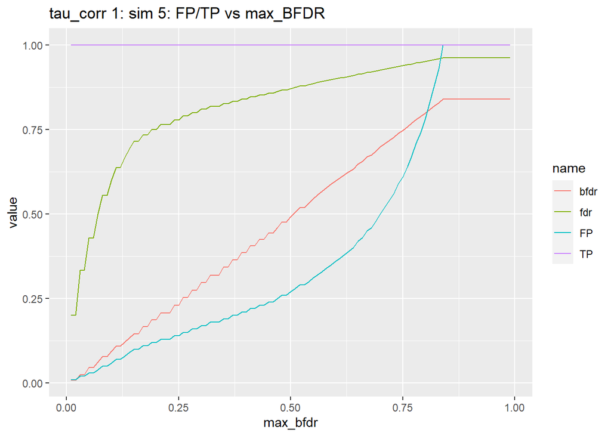

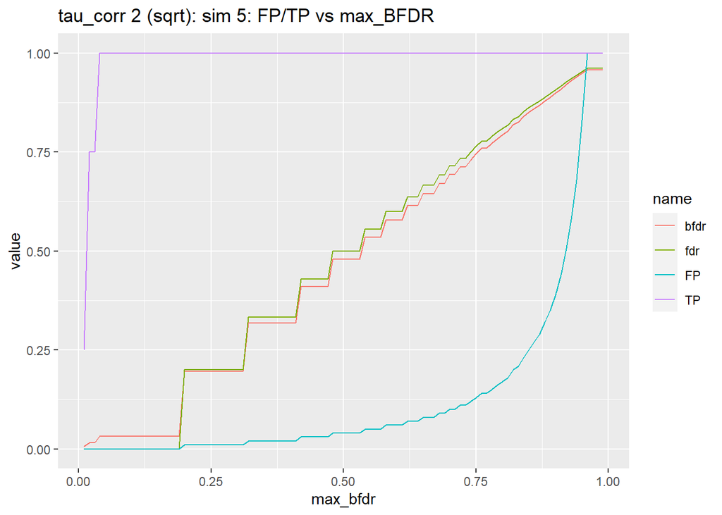

### sim 6

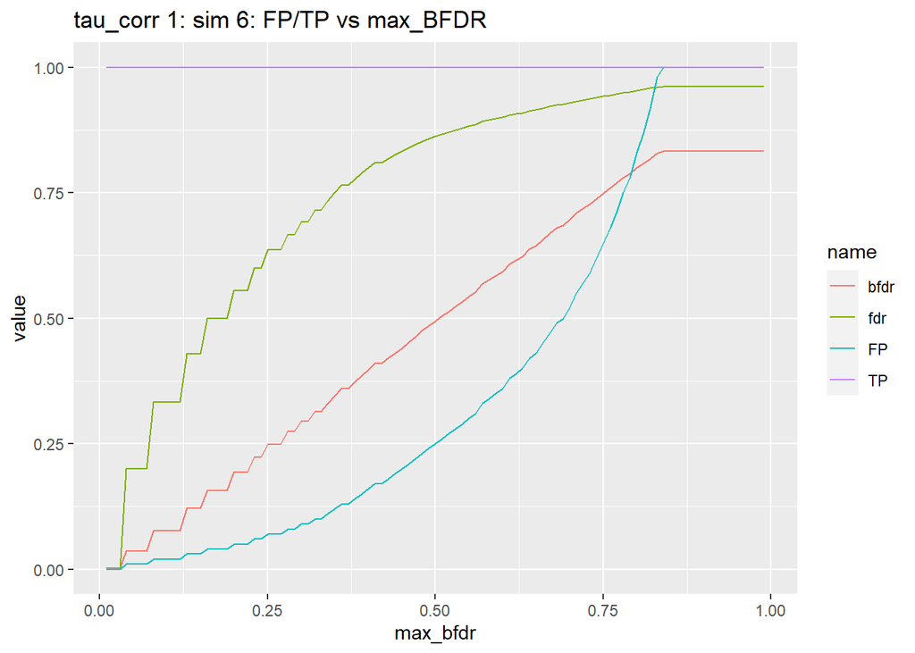

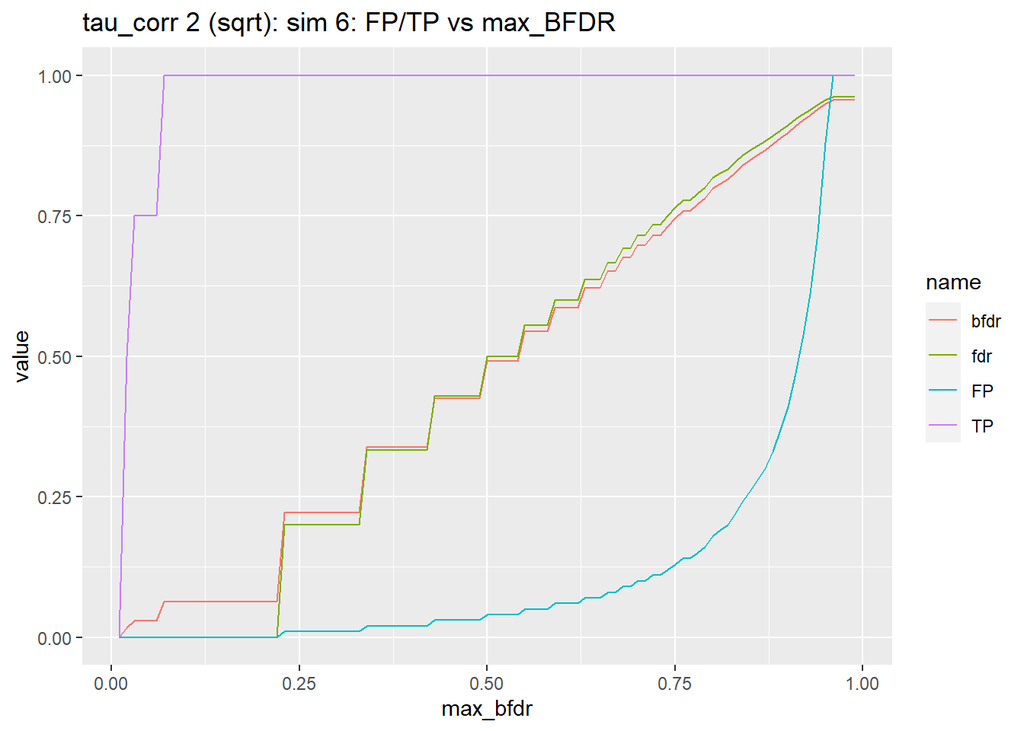

### sim 7

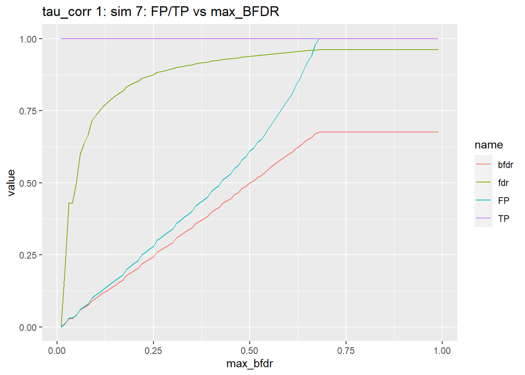

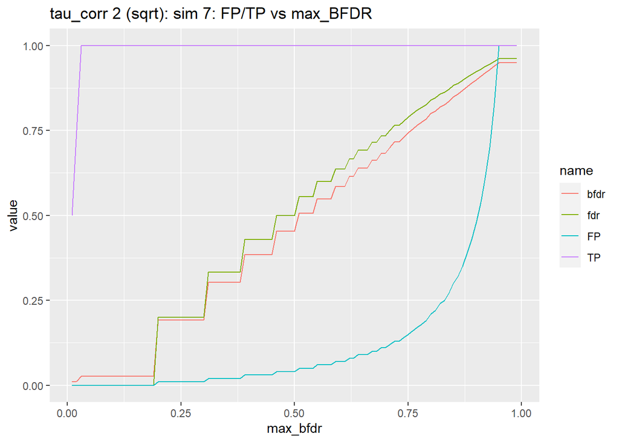

### sim 8

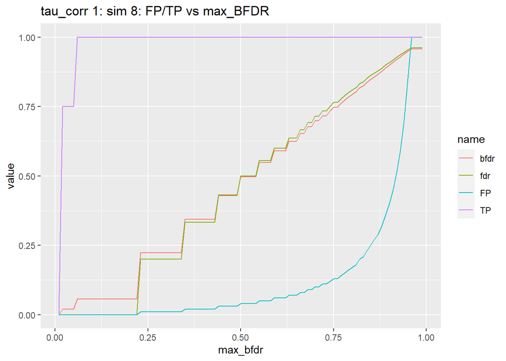

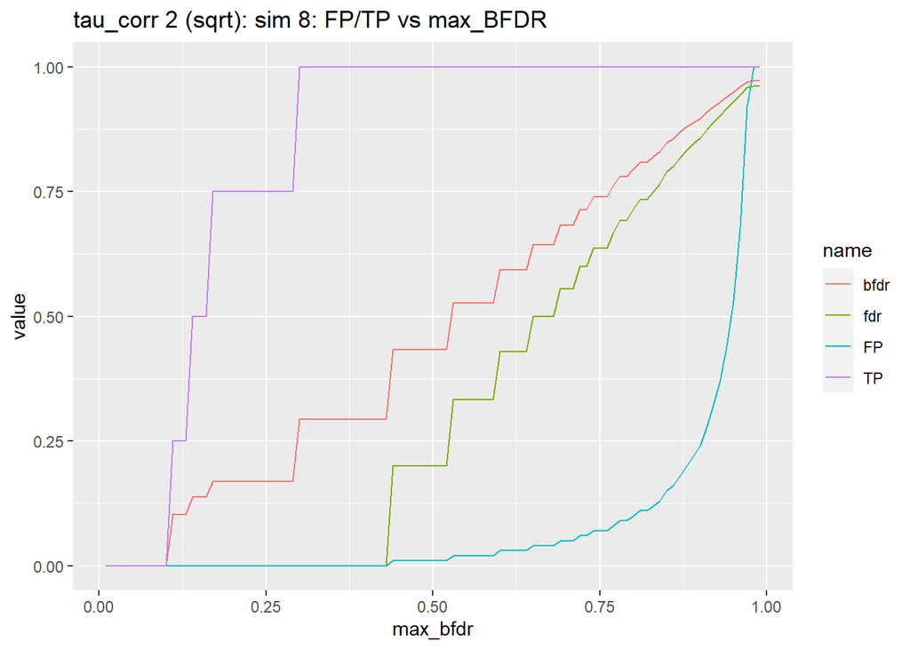

### sim 9

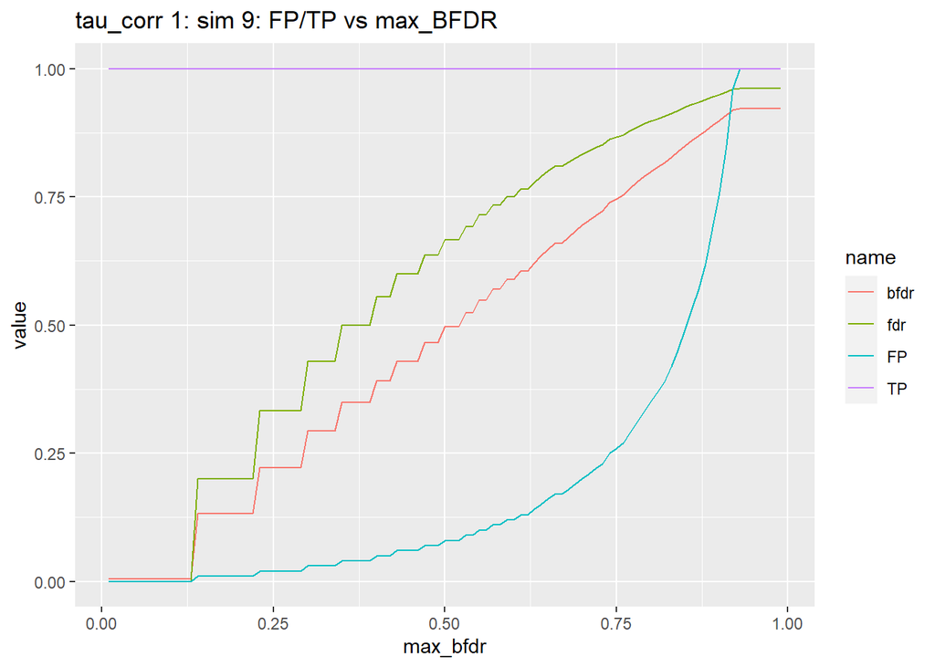

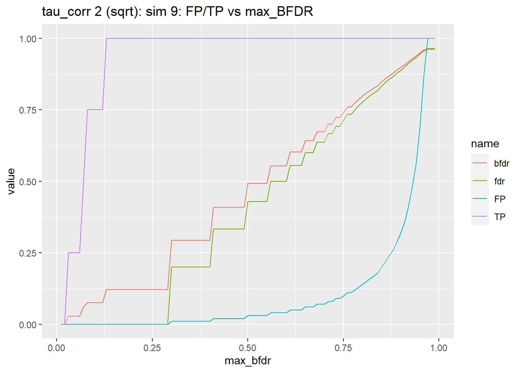

### sim 10

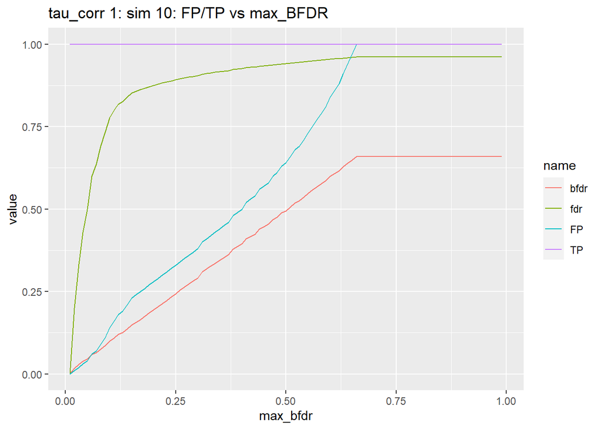

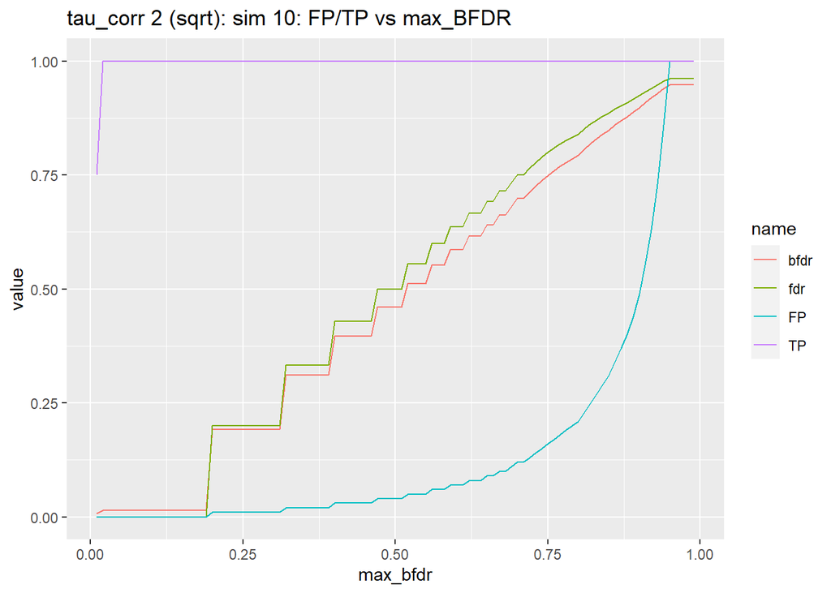

### sim 11

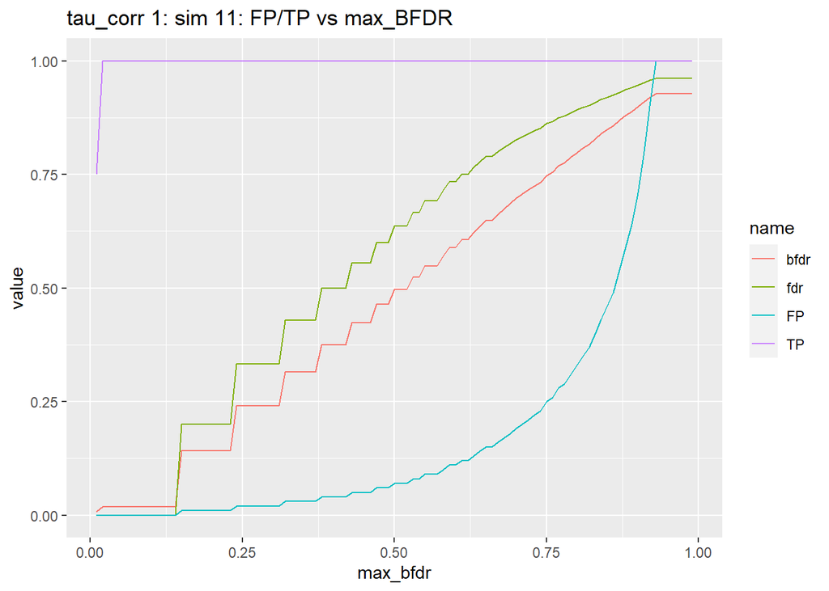

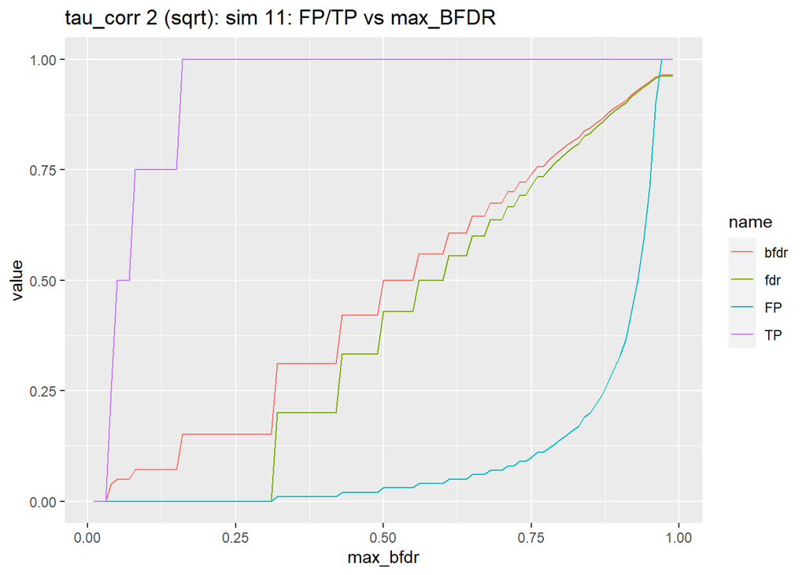

### sim 12

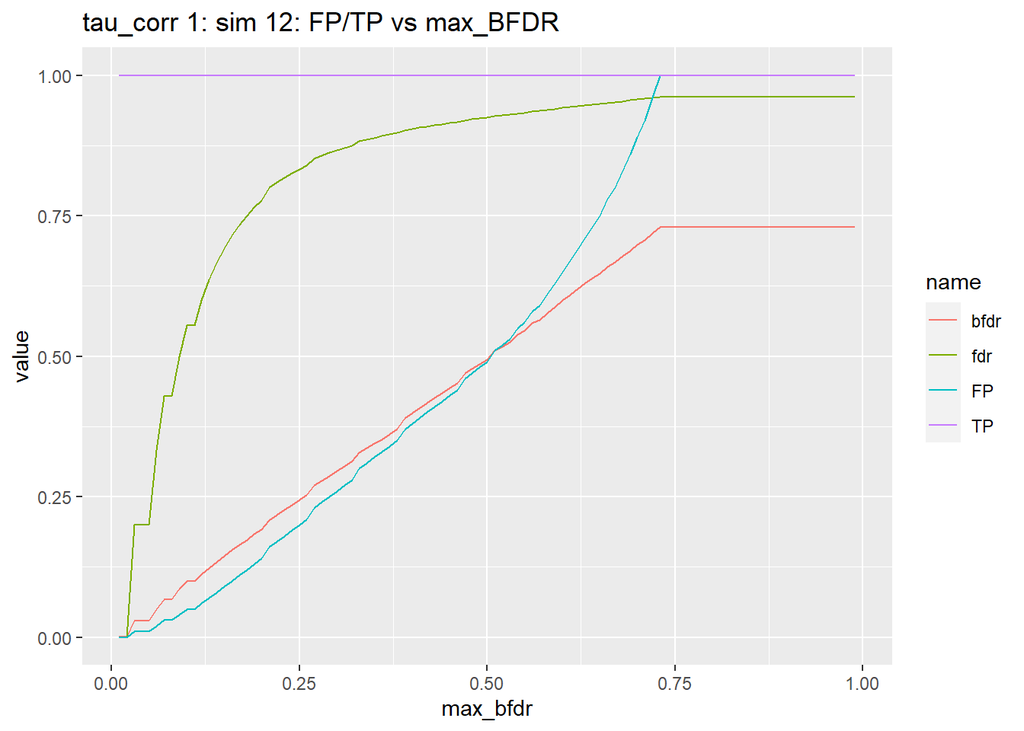

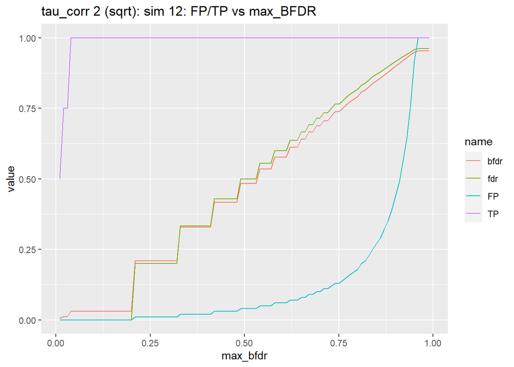

### sim 13

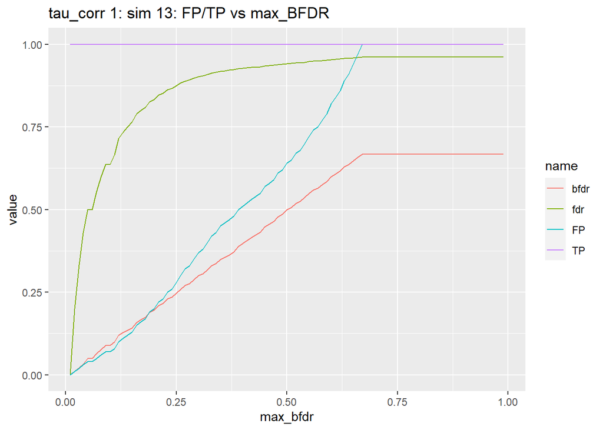

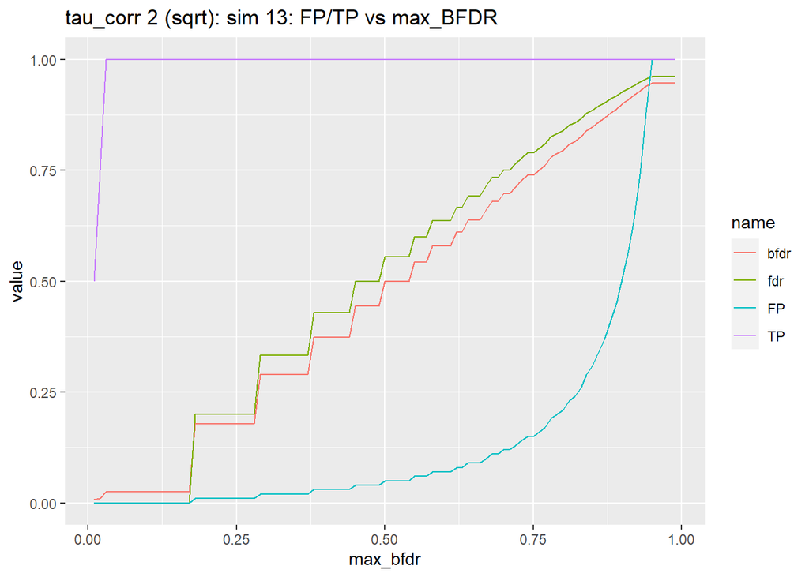

### sim 14

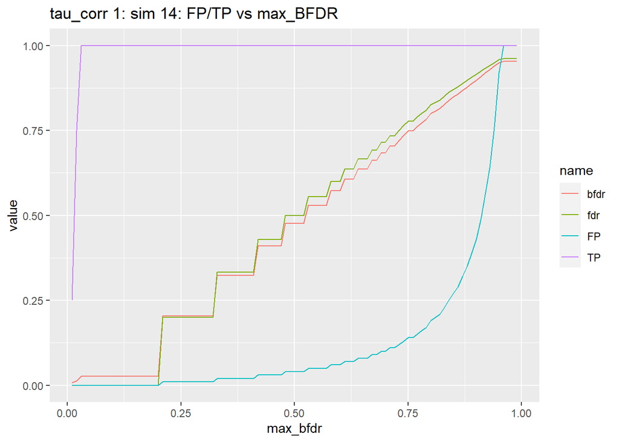

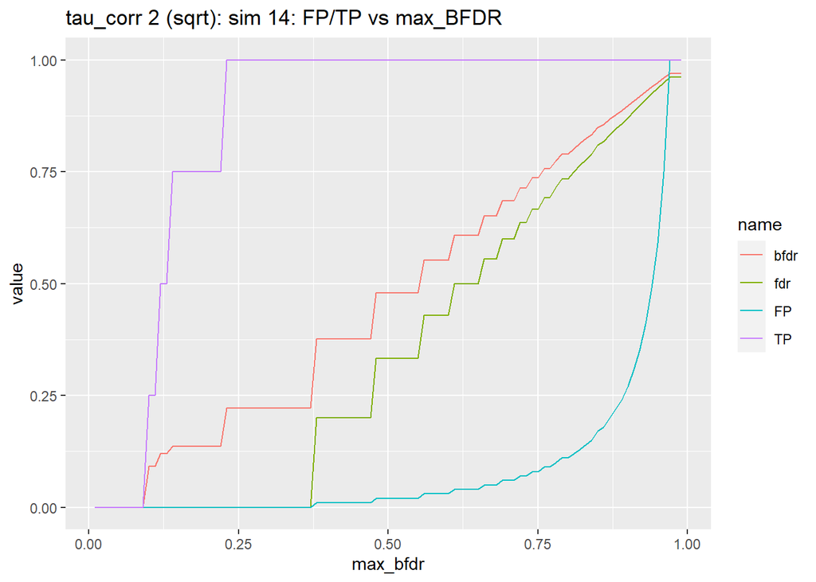

### sim 15

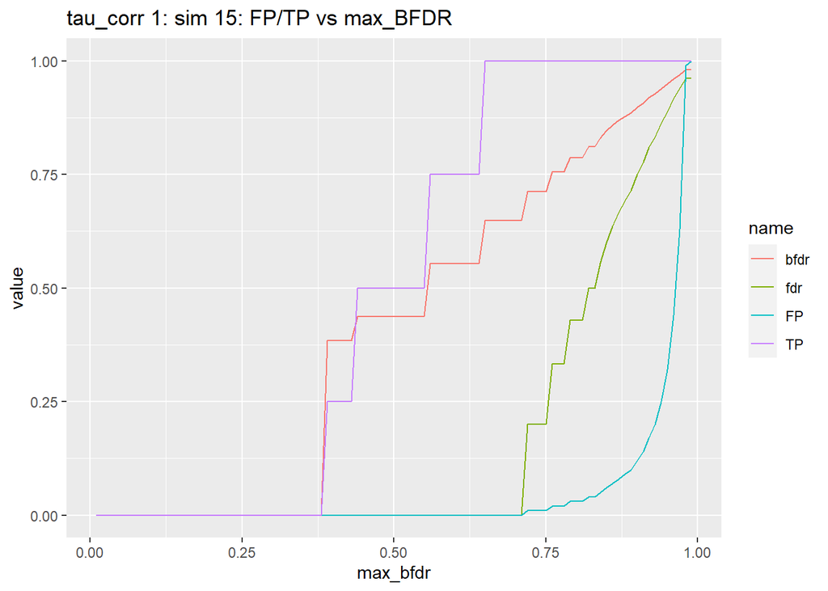

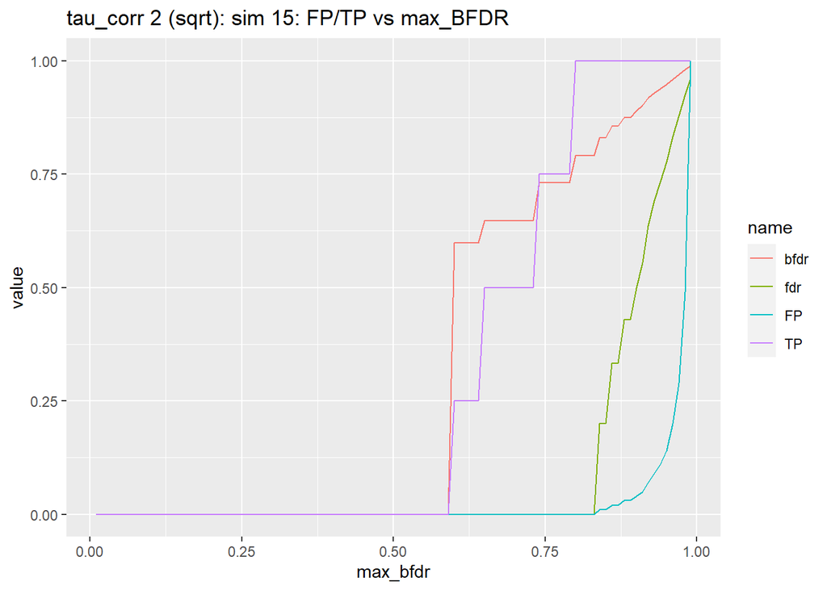

## comments

My assessments of the plots:

- Good: sim 1, 2, 8, 9, 11, 14
- Acceptable: sim 4
- early FPs, but roughly similar shape: sim 3, 5, 6, 12, 13,
- bad: sim 7, 10, 15
- also worth nothing that sims 1:5 were trained for 1M epochs, 6:15 for 500K epochs. Most appeared to actually do well starting around 125k epochs.

This seems like it is going to work. I do suspect that there may have been training issues in some of these — whether under/overtraining — since I just trained all of these for a fixed number of epochs (admittedly v. large), used the final epoch’s model/results, and only 1 model on each dataset. A common practice appears to be training several models on each dataset and using the one with the lowest training error; Rockova & Polson do this, for example).

### $\dfrac{d_1}{m_2^{eff}}$ or $\sqrt{\dfrac{d_1}{m_2^{eff}}}$?

- Also, it might make more sense to correct $\tau_1$ by the **square root** of $\dfrac{d_1}{m_{eff}}$, i.e.:

$$\tau_1^{corr} = \hat{\tau}_1 \times
\sqrt{ \dfrac{d_1}{m_2^{eff}} }$$
- **put into 2nd plots above.**

### diagnostics

```r
good <- c(1, 2, 4, 8, 9, 11, 14)
meh <- c(3, 5, 6, 12, 13)
ugh <- c(7, 10, 15)
```

Looking at BFDR plots: